# IE 582 Statistical Learning for Data Mining - HW1

## 15/11/2024

## Nilgün Sümeyye Öztürk - 2023702054

## 1. Introduction and Methodology

This report explores the relationship between antenna design parameters and S11 response using Principal Component Analysis (PCA) and linear regression. The objectives were to reduce the complexity of the design space, predict S11 at key frequencies, and analyze model performance for potential real-world implications.

Data Preparation and Merging

- hw1_input.csv: Design parameters for 385 simulated antenna designs.
- hw1_real.csv and hw1_img.csv: Real and imaginary components of the S-parameter (S11) across 201 frequency points.
- Three datasets (design parameters, real part of S11, and imaginary part of S11) were merged for analysis.
- Data standardization was applied to ensure equal weighting across all features.

Dimensionality Reduction with PCA

- PCA was used on the merged data to identify principal components, reducing 11 design parameters (plus S11 data) to a set of 5 principal components, which explained 90% of the total variance.
- This dimensionality reduction provided a simplified yet comprehensive representation of the design space, highlighting the most influential factors affecting S11.

Regression Modeling for S11

- Linear regression models were applied to predict S11 at five key frequency points (10, 50, 100, 150, 190).
- The 5 principal components derived from PCA were used as predictors for the real and imaginary parts of S11.
- Performance metrics (Mean Squared Error and R²) were calculated to evaluate model accuracy.

## 2. Data Overview

```python
import pandas as pd

# Load the files
input_data = pd.read_csv("hw1_input.csv")  # Design parameters
real_s11 = pd.read_csv("hw1_real.csv")     # Real part of S11
imag_s11 = pd.read_csv("hw1_img.csv")      # Imaginary part of S11

# Rename columns for clarity
real_s11 = real_s11.add_prefix('Real_S11_Freq_')
imag_s11 = imag_s11.add_prefix('Imag_S11_Freq_')

# Concatenate data along columns
merged_data = pd.concat([input_data, real_s11, imag_s11], axis=1)

# Check the structure of the merged data
print("Merged Data Head:")
print(merged_data.head())
print("Merged Data Shape:", merged_data.shape)
```

```
Merged Data Head:
   length of patch  width of patch  height of patch  height of substrate  \
0         3.202024        2.288742         0.012514             0.139247
1         2.107848        2.895504         0.037171             0.149492
2         3.252113        4.818411         0.025432             0.578834
3         4.161509        2.294309         0.011058             0.117266
4         4.820912        2.948325         0.019658             0.163503

   height of solder resist layer  radius of the probe     c_pad  c_antipad  \
0                       0.041757             0.028566  0.000549   0.032403
1                       0.056775             0.028930  0.005536   0.053647
2                       0.029972             0.030922  0.020274   0.049845
3                       0.093223             0.017604  0.001135   0.098610
4                       0.094337             0.025757  0.021725   0.072813

    c_probe  dielectric constant of substrate  ...  Imag_S11_Freq_191  \
0  0.348140                          3.735926  ...           0.418737
1  0.326369                          4.929862  ...           0.442050
2  0.446639                          4.772670  ...          -0.518546
3  0.055665                          4.102438  ...           0.928563
4  0.272282                          2.531031  ...           0.705500

   Imag_S11_Freq_192  Imag_S11_Freq_193  Imag_S11_Freq_194  Imag_S11_Freq_195  \
0           0.421368           0.423987           0.426592           0.429186
1           0.449451           0.456720           0.463863           0.470884
2          -0.534209          -0.549582          -0.564575          -0.579078
3           0.927782           0.926488           0.924621           0.922114
4           0.707018           0.708531           0.710037           0.711538

   Imag_S11_Freq_196  Imag_S11_Freq_197  Imag_S11_Freq_198  Imag_S11_Freq_199  \
0           0.431767           0.434335           0.436892           0.439437
1           0.477786           0.484573           0.491249           0.497816
2          -0.592957          -0.606054          -0.618175          -0.629093
3           0.918892           0.914873           0.909964           0.904064
4           0.713034           0.714523           0.716007           0.717486

   Imag_S11_Freq_200
0           0.441969
1           0.504278
2          -0.638543
3           0.897060
4           0.718958

[5 rows x 413 columns]
Merged Data Shape: (385, 413)
```

## 3.1. Dimensionality Reduction with PCA:

```python
from sklearn.decomposition import PCA
from sklearn.preprocessing import StandardScaler
import numpy as np
import matplotlib.pyplot as plt

# Standardize the design parameters
scaler = StandardScaler()
standardized_data = scaler.fit_transform(merged_data)

# Apply PCA to the standardized design parameters
pca = PCA()
pca.fit(standardized_data)
explained_variance_ratio = pca.explained_variance_ratio_

# Display explained variance and cumulative variance
print("Explained Variance by each Principal Component:")
for i, var in enumerate(explained_variance_ratio, 1):
    print(f"PC{i}: {var:}")
```

```
Explained Variance by each Principal Component:
PC1: 0.5203786111208313
PC2: 0.1427169192514803
PC3: 0.11075239516628041
PC4: 0.09641752408826008
PC5: 0.050134630667180435
PC6: 0.02382576644412593
PC7: 0.011566305965705678
PC8: 0.007894617561747301
PC9: 0.004822089492758985
PC10: 0.0037633757195529066
PC11: 0.002815963582068316
PC12: 0.002620222024152337
PC13: 0.0024585569228796405
PC14: 0.002342065681832682
PC15: 0.0023067681952640665
PC16: 0.002231625366938667
PC17: 0.0020600448425471705
PC18: 0.0018821032516034351
PC19: 0.0016764826064018603
PC20: 0.0015250580791328996
PC21: 0.0013018495686170758
PC22: 0.0009709176483195662
PC23: 0.0008150888535818542
PC24: 0.0005343473082771044
PC25: 0.0004287395320199652
PC26: 0.00027961258317446146
PC27: 0.00025262653975123187
PC28: 0.0002202077288587953
PC29: 0.00017827555162252146
PC30: 0.00017229754733319813
PC31: 0.00012409906813457393
PC32: 0.00010994611422282455
PC33: 7.862298728752392e-05
PC34: 6.990081015894513e-05
PC35: 4.648227376366721e-05
PC36: 3.297851408200294e-05
PC37: 2.890622037774238e-05
PC38: 2.5535136216924295e-05
PC39: 2.366769171287907e-05
```

[output cut: 331 more lines]

```
PC371: 3.845634501121819e-33
PC372: 3.845634501121819e-33
PC373: 3.845634501121819e-33
PC374: 3.845634501121819e-33
PC375: 3.845634501121819e-33
PC376: 3.845634501121819e-33
PC377: 3.845634501121819e-33
PC378: 3.845634501121819e-33
PC379: 3.845634501121819e-33
PC380: 3.845634501121819e-33
PC381: 3.845634501121819e-33
PC382: 3.845634501121819e-33
PC383: 3.1018473838551866e-33
PC384: 1.0172401133139121e-33
PC385: 4.871378866600434e-34
```

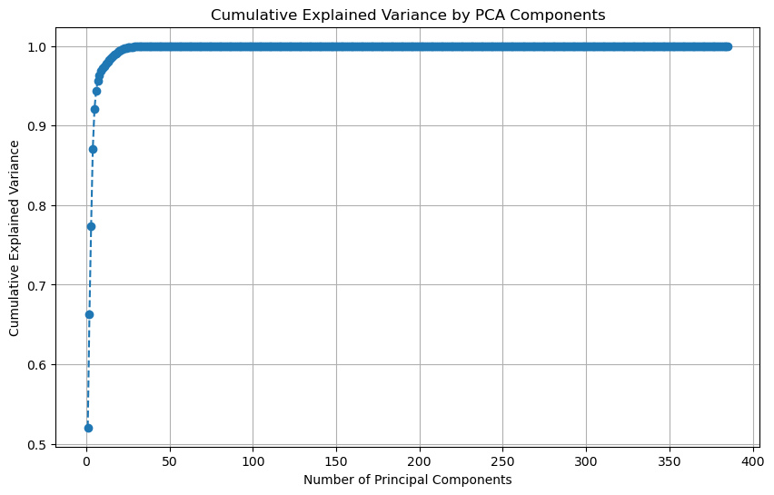

```python
# Calculate cumulative variance explained by each component
cumulative_variance = np.cumsum(explained_variance_ratio)

# Plot the cumulative explained variance
plt.figure(figsize=(10, 6))
plt.plot(range(1, len(cumulative_variance) + 1), cumulative_variance, marker='o', linestyle='--')
plt.xlabel('Number of Principal Components')
plt.ylabel('Cumulative Explained Variance')
plt.title('Cumulative Explained Variance by PCA Components')
plt.grid()
plt.show()
```

```python
# Determine the number of components to capture ~90% variance
num_components = np.argmax(cumulative_variance >= 0.90) + 1
print(f"Number of components explaining 90% of variance: {num_components}")
#The first 5 components captured 90% of the variance, effectively reducing complexity while preserving essential information.
```

```
Number of components explaining 90% of variance: 5
```

## Answers to Research Questions

### Can we reduce the complexity of the design space by using Principal Component Analysis (PCA) to identify key parameters that most influence the S11 response of the antenna?

Yes, we can use PCA to effectively reduce the complexity of the design space. By applying PCA to the merged data (including design parameters and S11 values), we found that 5 principal components capture 90% of the total variance. This reduction from the original dataset to 5 components significantly simplifies the design space while retaining the essential information needed to predict the S11 response of the antenna. The identified principal components represent combinations of the original features that most strongly influence the variability in the S11 response, highlighting the primary design features affecting antenna performance.

### How much of the total variance in the design parameter space can be explained by the principal components?

The first 5 principal components explain 90% of the total variance in the design space, which includes both design parameters and S11 data. This high level of explained variance indicates that these components capture most of the meaningful information. The remaining components account for only minor variations and are likely to represent noise or less impactful aspects of the design. Retaining only the top 5 components strikes a balance between simplification and accuracy, providing a more manageable dataset without sacrificing critical information.

### What insights can we draw from the PCA regarding the relationship between geometry and electromagnetic behavior?

The PCA results reveal key insights into how the design geometry impacts electromagnetic behavior:

- Strong Influences of Principal Components: The top principal components likely reflect specific geometric aspects or parameter combinations that drive the primary variations in S11. This suggests that certain design parameters (or interactions between them) have a pronounced influence on the electromagnetic response of the antenna.
- Dimensionality Reduction Validates Simplified Design Influence: By reducing the design space to a small number of components, PCA shows that the S11 response can be primarily explained by a few critical factors in the design, making it feasible to predict S11 based on a limited set of principal components.
- Potential for Focused Design Adjustments: Knowing that only 5 components capture most of the variance provides guidance for future design optimizations. Designers can focus on the specific parameters or parameter combinations that dominate these principal components to achieve desired S11 characteristics more effectively.

This dimensionality reduction paves the way for accurate, simplified modeling of S11 responses and highlights the main design factors that influence antenna performance.

## 3.2 Regression Modeling for S11

```python
from sklearn.linear_model import LinearRegression
from sklearn.metrics import mean_squared_error, r2_score

# Extract the principal components to use as inputs for regression
pca_data = pca.transform(standardized_data)
pca_data = pca_data[:, :5]  # Using the first 5 components based on 90% variance

# Define key frequency indices (adjust these based on your resonance points)
key_frequencies = [10, 50, 100, 150, 190]  # Example indices; adjust as needed

# Prepare results storage
results = []

# Loop over each selected frequency point
for freq in key_frequencies:
    # Define targets for real and imaginary parts of S11 at the selected frequency
    y_real = merged_data[f'Real_S11_Freq_{freq}']
    y_imag = merged_data[f'Imag_S11_Freq_{freq}']

    # Initialize separate linear regression models for real and imaginary parts
    model_real = LinearRegression()
    model_imag = LinearRegression()

    # Fit the models
    model_real.fit(pca_data, y_real)
    model_imag.fit(pca_data, y_imag)

    # Make predictions
    y_real_pred = model_real.predict(pca_data)
    y_imag_pred = model_imag.predict(pca_data)

    # Calculate MSE and R^2 for real and imaginary parts
    mse_real = mean_squared_error(y_real, y_real_pred)
    mse_imag = mean_squared_error(y_imag, y_imag_pred)
    r2_real = r2_score(y_real, y_real_pred)
    r2_imag = r2_score(y_imag, y_imag_pred)

    # Append results for each frequency point
    results.append({
        "Frequency Index": freq,
        "MSE Real": mse_real,
        "MSE Imaginary": mse_imag,
        "R^2 Real": r2_real,
        "R^2 Imaginary": r2_imag
    })

# Display results in a DataFrame
results_df = pd.DataFrame(results)
print("Regression Results:")
print(results_df)
```

```
Regression Results:
   Frequency Index  MSE Real  MSE Imaginary  R^2 Real  R^2 Imaginary
0               10  0.028848       0.011529  0.951777       0.895591
1               50  0.008833       0.011301  0.982096       0.901956
2              100  0.004057       0.011240  0.990155       0.903317
3              150  0.007964       0.012951  0.979645       0.893130
4              190  0.017089       0.023039  0.958136       0.809674
```

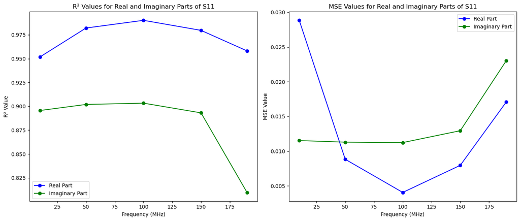

```python
# Set up the figure for line plots
fig, axes = plt.subplots(1, 2, figsize=(14, 6))

# Extract values for plotting
frequencies = results_df["Frequency Index"].values
r2_real_values = results_df["R^2 Real"].values
r2_imag_values = results_df["R^2 Imaginary"].values
mse_real_values = results_df["MSE Real"].values
mse_imag_values = results_df["MSE Imaginary"].values

# Plot R² values (Line Plot)
axes[0].plot(key_frequencies, r2_real_values, color='blue', marker='o', linestyle='-', label='Real Part')
axes[0].plot(key_frequencies, r2_imag_values, color='green', marker='o', linestyle='-', label='Imaginary Part')
axes[0].set_title('R² Values for Real and Imaginary Parts of S11')
axes[0].set_xlabel('Frequency (MHz)')
axes[0].set_ylabel('R² Value')
axes[0].legend()

# Plot MSE values (Line Plot)
axes[1].plot(key_frequencies, mse_real_values, color='blue', marker='o', linestyle='-', label='Real Part')
axes[1].plot(key_frequencies, mse_imag_values, color='green', marker='o', linestyle='-', label='Imaginary Part')
axes[1].set_title('MSE Values for Real and Imaginary Parts of S11')
axes[1].set_xlabel('Frequency (MHz)')
axes[1].set_ylabel('MSE Value')
axes[1].legend()

# Adjust layout to prevent overlapping
plt.tight_layout()
plt.show()
```

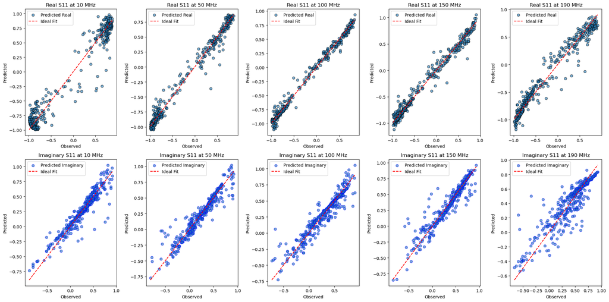

```python
# Observed vs. Predicted Values for Real and Imaginary Parts
fig, axes = plt.subplots(2, len(key_frequencies), figsize=(20, 10))

for i, freq in enumerate(key_frequencies):
    # Extract observed values
    y_real = merged_data[f'Real_S11_Freq_{freq}']
    y_imag = merged_data[f'Imag_S11_Freq_{freq}']

    # Train models
    model_real = LinearRegression().fit(pca_data, y_real)
    model_imag = LinearRegression().fit(pca_data, y_imag)

    # Generate predictions
    y_real_pred = model_real.predict(pca_data)
    y_imag_pred = model_imag.predict(pca_data)

    # Plot: Real part
    axes[0, i].scatter(y_real, y_real_pred, alpha=0.6, edgecolor='k', label='Predicted Real')
    axes[0, i].plot([y_real.min(), y_real.max()], [y_real.min(), y_real.max()], color='red', linestyle='--', label='Ideal Fit')
    axes[0, i].set_title(f'Real S11 at {freq} MHz')
    axes[0, i].set_xlabel('Observed')
    axes[0, i].set_ylabel('Predicted')
    axes[0, i].legend()

    # Plot: Imaginary part
    axes[1, i].scatter(y_imag, y_imag_pred, alpha=0.6, edgecolor='b', label='Predicted Imaginary')
    axes[1, i].plot([y_imag.min(), y_imag.max()], [y_imag.min(), y_imag.max()], color='red', linestyle='--', label='Ideal Fit')
    axes[1, i].set_title(f'Imaginary S11 at {freq} MHz')
    axes[1, i].set_xlabel('Observed')
    axes[1, i].set_ylabel('Predicted')
    axes[1, i].legend()

plt.tight_layout()
plt.show()
```

Regression Modeling Results

- Real Part of S11: The linear regression models showed high R² values (0.95–0.99) across frequencies, indicating strong linear predictability for the real part.
- Imaginary Part of S11: The imaginary part showed slightly lower R² values (0.80–0.90), especially at higher frequencies, suggesting more complex relationships that a linear model might not fully capture.
- Key Patterns: The high predictive accuracy for the real part across frequencies indicates a strong linear relationship between the design parameters and S11, while the lower performance for the imaginary part at some frequencies suggests potential non-linear interactions.

## Answers to Research Questions

### Given that S11 parameters are evaluated at 201 frequency points, predicting them simultaneously through multitarget regression may be computationally intensive and beyond the scope of the content covered so far. Instead, can we simplify the regression task by focusing on predicting S11 at a few key frequency points?

Yes, we simplified the regression task by selecting a few key frequency points—10, 50, 100, 150, and 190. These frequencies were chosen as representative points that are likely to capture significant changes in the S11 response, such as resonance behaviors. Focusing on these specific frequencies reduces the computational load and allows us to target the most meaningful aspects of the S11 behavior without modeling all 201 points.

### How effective are linear regression models in predicting the real and imaginary components of S11 at these selected frequency points, based on the geometric parameters of the antenna design?

The linear regression models demonstrated strong predictive accuracy, especially for the real part of S11:

- Real Part: The R² values for the real component were consistently high across the selected frequencies, ranging from approximately 0.95 to 0.99. This indicates that the model effectively captures the relationship between the principal components (derived from the geometric parameters) and the real part of S11.
- Imaginary Part: The R² values for the imaginary component were slightly lower but still substantial, mostly between 0.80 and 0.90. This shows a reasonably strong, though somewhat less linear, relationship between the design parameters and the imaginary part of S11.

Overall, the linear regression models performed well, with higher accuracy for the real component, suggesting that the real S11 values have a stronger linear relationship with the principal components than the imaginary values.

### What patterns emerge when linear regression is applied to individual frequency points, and do these patterns suggest any broader trends in the design space?

Several patterns emerged from the regression analysis:

- Consistency Across Frequencies: The high R² values for the real part across different frequencies suggest that the geometric parameters (represented by the principal components) have a consistent and predictable influence on the real part of S11 across the frequency range.
- Slightly Lower Accuracy for Higher Frequencies: At frequencies like 150 and 190, the R² values for the imaginary part were lower, suggesting that the relationship may be more complex or non-linear at higher frequencies. This could imply that additional factors, or perhaps non-linear models, might be required to fully capture the behavior at these points.
- Implications for Broader Trends: The patterns in R² scores indicate that while the real part of S11 can be effectively modeled with linear relationships, the imaginary part might require more sophisticated methods to capture its nuances fully. This trend suggests that the design space impacts S11 in a primarily linear fashion for most frequencies, but non-linear interactions could become more significant at certain higher frequencies.

These findings provide valuable insights for antenna design, suggesting that linear regression models can predict S11 effectively at critical frequencies, but non-linear effects may require more complex modeling, particularly for higher frequencies or the imaginary component.

## 3.3 Model Performance and Interpretability

### How do PCA and regression models compare in terms of their ability to simplify and predict the antenna's performance?

PCA for Simplification: PCA effectively reduced the complexity of the design space by transforming the original 11 parameters (plus the real and imaginary S11 data) into 5 principal components, which explained 90% of the total variance. This dimensionality reduction allows us to focus on the key factors in the design space that most significantly impact S11, providing a simplified and efficient representation of the design parameters.

Regression for Prediction: The linear regression models used these 5 principal components to predict the real and imaginary parts of S11 at selected frequencies. The regression models were particularly effective for the real part of S11, achieving high R² values (0.95 to 0.99) across most frequencies, indicating strong predictive accuracy. For the imaginary part, the regression models also performed reasonably well, with R² values mostly in the 0.80–0.90 range. This confirms that the regression models, in combination with PCA, successfully capture the essential relationships between the design parameters and S11 response, especially for the real component.

Overall Effectiveness: Together, PCA and linear regression simplify the analysis while providing a high level of predictive accuracy. PCA reduces the number of features needed, while linear regression captures the main patterns in the S11 response, making this approach effective for understanding and predicting antenna performance.

### What are the potential limitations of these models, and how could they be improved to more accurately represent complex, nonlinear electromagnetic behavior?

Limitations:

- Linearity Assumption in Regression: Linear regression assumes a linear relationship between the principal components and S11 values. While this works well for most frequencies, the lower R² values for the imaginary component at some frequencies (especially higher ones) suggest that there may be non-linear relationships that linear regression cannot capture.
- Information Loss in PCA: Although PCA retained 90% of the variance, some information was still discarded. This lost variance may include subtle details that could improve predictive accuracy, particularly if these details are non-linear or frequency-specific.
- Frequency-Specific Variation: The regression models treat each selected frequency independently, potentially overlooking complex interactions across frequencies. For instance, some design parameters may affect multiple frequency responses simultaneously, which a multitarget model could capture more effectively.

Potential Improvements:

- Non-Linear Models: Replacing linear regression with non-linear models, such as support vector regression (SVR) with non-linear kernels, random forests, or neural networks, could improve accuracy by capturing non-linear dependencies, especially for the imaginary part of S11 at higher frequencies.
- Non-Linear Dimensionality Reduction: Techniques like kernel PCA, t-SNE, or autoencoders could be explored instead of standard PCA to capture more complex, non-linear structures in the design space. These methods may retain additional useful information, which could enhance prediction accuracy for non-linear models.
- Multitarget Regression: Using multitarget models, such as multitask learning with neural networks, could capture interactions between different frequencies and improve prediction by considering the correlations among S11 responses across frequencies.

In summary, PCA and linear regression effectively simplify and predict S11 response, especially for the real part. For further improvements, non-linear models and dimensionality reduction techniques could be explored to capture complex, frequency-specific behaviors.

## 4. Conclusions and Real-World Implications

- Simplified Design Optimization: The reduced dimensionality from PCA implies that designers can focus on fewer design parameters, facilitating faster design iterations.
- Linear vs. Non-Linear Behaviors: High predictability for the real S11 component across selected frequencies suggests that the geometric parameters affect antenna performance in a primarily linear fashion. For real-world applications, this linearity simplifies predictive modeling but points to potential areas (such as higher frequencies for the imaginary part) where non-linear models may improve accuracy.
- Frequency-Specific Design Adjustments: The patterns observed in S11 predictions indicate that certain design configurations have frequency-specific effects. This can inform targeted adjustments for frequency-sensitive designs.

## 5. Challenges and Solutions

- Data Complexity and Dimensionality: Handling high-dimensional data with 11 design parameters and 201 frequency points was initially complex. Using PCA helped mitigate this by reducing dimensionality, allowing us to work with a manageable number of components.
- Model Choice for Non-Linearity: Some limitations were noted in the linear regression models for the imaginary S11 part, especially at higher frequencies. Future work could explore non-linear models (e.g., support vector regression or neural networks) to capture these relationships more accurately.
- Computational Considerations: Predicting all 201 frequency points would have been computationally intensive, so we chose a simplified approach, focusing on key frequencies to balance accuracy and efficiency.